# PPOL 563 - Problem Set 1

Anandi Gupta

### Question 1: This database is not a complete representation of all power plants. In fact, it only covers about 30% of all Solar energy produced worldwide. Please write a brief paragraph you would include in an email to colleagues describing the scope and source of the limitations of this data

The visualizations contained in this report utilize data for a sample of approximately 35,000 power plants from 167 countries, and covers both non-renewable (eg. coal, gas) and renewable energy (eg. solar, hydro). For each plant, the dataset contains information on plant capacity, generation, ownership, and fuel type as well as information on the geographic location of the plants. Note, however, that while this appears to be a fairly representative dataset in terms of geographic coverage, it is not a complete representation of all power plants. Further, the data is likely not missing at random. Rather, smaller distributed plants producing renewables (eg. solar and wind) are more likely to be missing from the data than larger plants (like thermal and larger hydro plants), particularly as the database is created based on reporting in public documents. For example, the database covers powers plants generating only approximately 30% of all solar energy produced worldwide. This is an important consideration to be aware of when comparing trends such as capacity across fuel types, as these comparisons may be misleading due to the missing capacity for certain fuel types.

### Question 2: Reproduce the histogram plot below, in which we are visualizing commissioning_year with a bin width of 10. Please insert a meaningful title and subtitle.

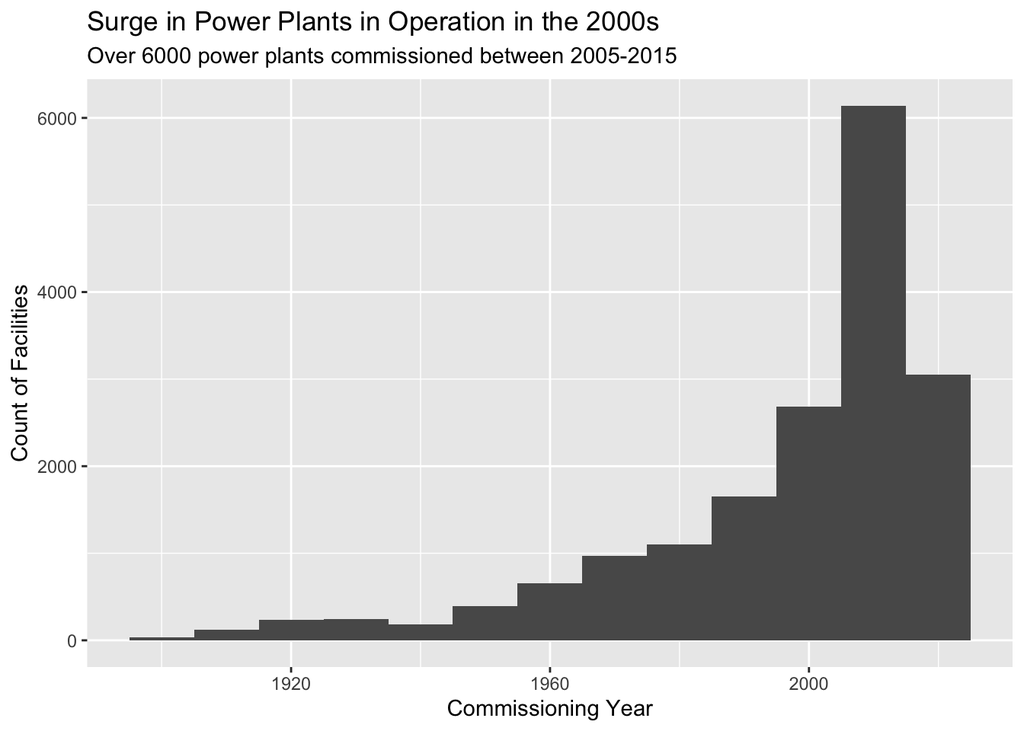

```r
ggplot(d1, aes(x=commissioning_year)) +
  geom_histogram(binwidth=10) +
  labs(title = "Surge in Power Plants in Operation in the 2000s",
       subtitle = "Over 6000 power plants commissioned between 2005-2015",
        x = "Commissioning Year",
        y = "Count of Facilities")
```

### Question 3: Reproduce the boxplot below, in which we are visualizing capacity_mw, grouped by primary_fuel (which is sorted by the median of capacity_mw). Take note of the logged X axis, and please insert a meaningful title and subtitle.

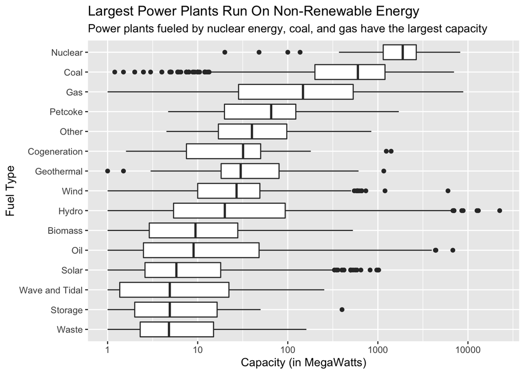

```r
ggplot(d1, aes(x = reorder(primary_fuel, capacity_mw, FUN = median), y = capacity_mw)) +
  geom_boxplot() + scale_y_log10() +
  labs(title = "Largest Power Plants Run On Non-Renewable Energy",
  subtitle = "Power plants fueled by nuclear energy, coal, and gas have the largest capacity",
  x = "Fuel Type",
  y = "Capacity (in MegaWatts)") + coord_flip()
```

### Question 4: Reproduce the barchart below, visualizing primary_fuel and colored by renewable. Please insert a meaningful title and subtitle.

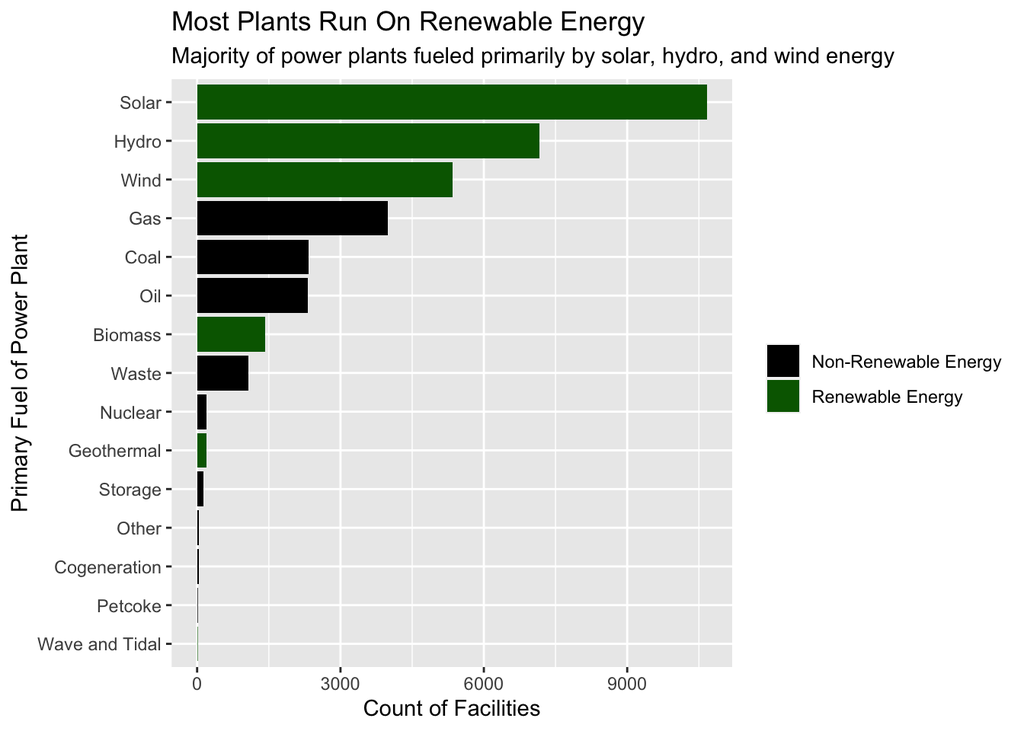

```r
d1 %>%
    group_by(primary_fuel, renewable) %>%
    summarise(count = n()) %>%
  ggplot(aes(x = reorder(primary_fuel,(count)), y = count)) +
  geom_bar(stat = 'identity',  aes(fill = renewable)) +
  coord_flip() + scale_fill_manual(values = c("black", "darkgreen")) +
  labs(title = "Most Plants Run On Renewable Energy",
  subtitle = "Majority of power plants fueled primarily by solar, hydro, and wind energy",
  x = "Primary Fuel of Power Plant", y = "Count of Facilities") +
  theme(legend.title=element_blank())
```

### Question 5: Reproduce the grouped barchart below, visualizing counts of the number of facilities in each continent, colored by the renewable variable. Notice the location of the text labels on each bar - this is tricky to do, so you may have to do some googling. Inserting your own meaningful title and subtitle.

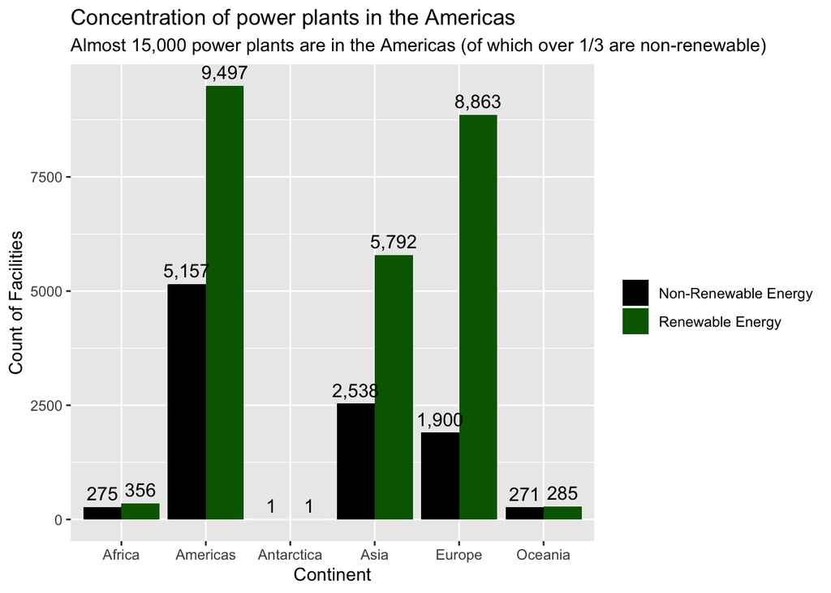

```r
d1 %>%
    group_by(continent, renewable) %>%
    summarise(count = n()) %>% ggplot(aes(continent, count, fill = renewable)) +
  geom_bar(stat = "identity", position = 'dodge') +
  scale_fill_manual(values = c("black", "darkgreen")) +
  theme(legend.title=element_blank()) +
  geom_text(aes(label = scales::comma(round(count), accuracy=1)),
    colour = "black", size = 4,
    vjust = -0.5, position = position_dodge(.9))+
  labs(title = "Concentration of power plants in the Americas",
  subtitle = "Almost 15,000 power plants are in the Americas (of which over 1/3 are non-renewable)",
  x = "Continent", y = "Count of Facilities")
```

### Question 6: Reproduce the 100% stacked barchart below. This is a visualiation of a count of facilities by continent grouped by the renewable variable, and then computed as proportions.

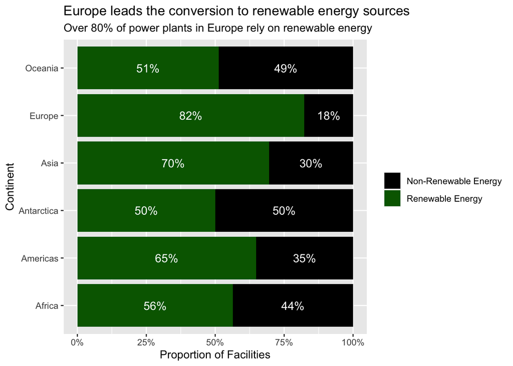

```r
d1 %>%
    group_by(continent, renewable) %>%
  dplyr::tally()%>%
  dplyr::mutate(percent=n/sum(n)) %>% ggplot(aes(x= continent, y = n,fill = renewable)) +
  geom_bar(stat="identity", position ="fill") +
  geom_text(aes(label=paste0(sprintf("%1.0f", percent*100),"%")),
                     position=position_fill(vjust=0.5), colour="white", size =4) +
  coord_flip() +  scale_fill_manual(values = c("black", "darkgreen")) +
  theme(legend.title=element_blank()) + scale_y_continuous(labels = scales::percent) +
  labs(title = "Europe leads the conversion to renewable energy sources",
  subtitle = "Over 80% of power plants in Europe rely on renewable energy",
  x = "Continent", y = "Proportion of Facilities")
```

### Question 7: Reproduce the scatterplot below, inserting your own meaningful title and subtitle.

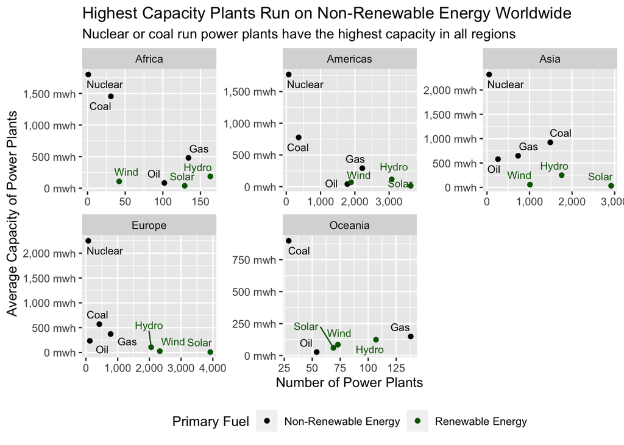

```r
x <- d1 %>%
    group_by(continent, primary_fuel, renewable) %>%
  summarise(mean_capacity = mean(capacity_mw, na.rm = TRUE), count = n()) %>%
  filter(continent != "Antarctica") %>% filter(primary_fuel %in% c("Solar", "Hydro", "Wind", "Gas", "Coal", "Oil", "Nuclear"))

ggplot(x, aes(count, mean_capacity, color = renewable)) + geom_point() + scale_color_manual(values = c("black", "darkgreen")) + scale_y_continuous(labels = label_number(suffix = " mwh", big.mark = ",")) + scale_x_continuous(labels = label_number(big.mark = ","))  + labs(color='Primary Fuel', title = "Highest Capacity Plants Run on Non-Renewable Energy Worldwide",
  subtitle = "Nuclear or coal run power plants have the highest capacity in all regions",
  x = "Number of Power Plants", y = "Average Capacity of Power Plants") +ggrepel::geom_text_repel(aes(label = primary_fuel), size = 3, show_guide = F) +
  theme(legend.position = "bottom") +
  facet_wrap(~ continent, scales = "free")
```

### Question 8 - Chicago Public Schools - Create a bar chart of any element from your chosen dataset. The plot should either be colored, grouped or faceted to show how the key variable varies by some other categorical variable. It may be any orientation and it may be grouped, stacked, or 100% stacked.

```r
d2<-read.csv("https://raw.githubusercontent.com/alexlundry/ppol563_psets/main/chicago_schools.csv")
```

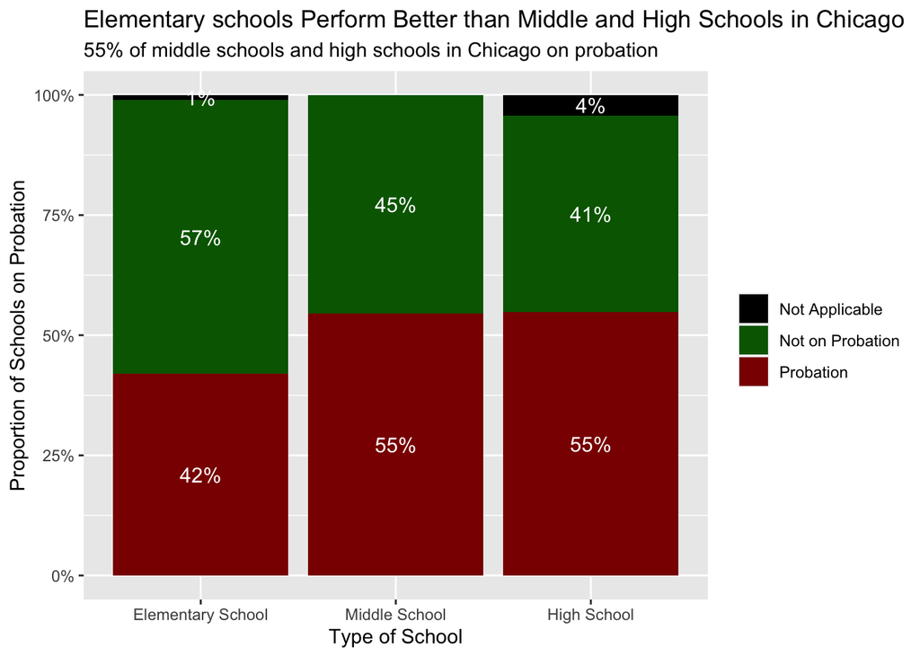

```r
d2 %>%
    group_by(elementary_middle_or_high_school, cps_performance_policy_status) %>% filter(elementary_middle_or_high_school != "NDA") %>% filter(cps_performance_policy_status != "NDA") %>%
  dplyr::tally()%>%
  dplyr::mutate(percent=n/sum(n)) %>% ggplot(aes(x= elementary_middle_or_high_school, y = n, fill = cps_performance_policy_status)) +
  geom_bar(stat="identity", position ="fill") +  scale_fill_manual(values = c("black", "darkgreen", "darkred")) +
  geom_text(aes(label=paste0(sprintf("%1.0f", percent*100),"%")),
                     position=position_fill(vjust=0.5), colour="white", size =4)   +
  theme(legend.title=element_blank()) + scale_y_continuous(labels = scales::percent) +
  labs(title = "Elementary schools Perform Better than Middle and High Schools in Chicago",
  subtitle = "55% of middle schools and high schools in Chicago on probation",
  x = "Type of School", y = "Proportion of Schools on Probation") +  scale_x_discrete(limits = c("ES", "MS", "HS"), labels = c("Elementary School", "Middle School", "High School"))
```

### Question 9: Create a boxplot of any numeric variable from your selected data, segmented by some relevant categorical data point. Be sure the boxplots are meaningfully sorted by some key statistic of the selected numeric variable

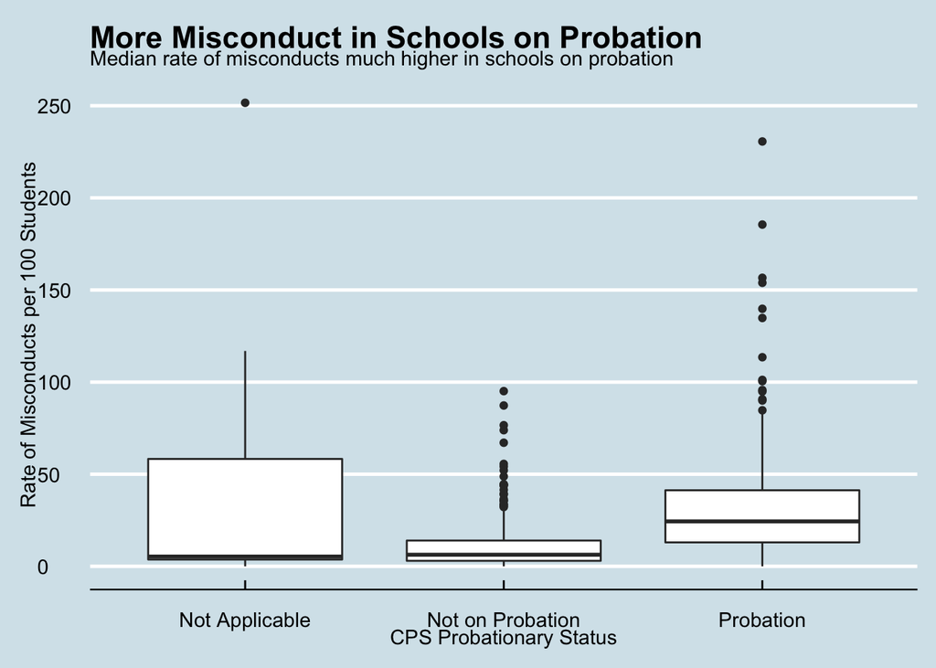

```r
d2 %>% filter(cps_performance_policy_status != "NDA") %>% ggplot(aes(x = reorder(cps_performance_policy_status, rate_of_misconducts_per_100_students, FUN = median), y = rate_of_misconducts_per_100_students)) + theme_economist() +
  geom_boxplot() +
  labs(title = "More Misconduct in Schools on Probation",
  subtitle = "Median rate of misconducts much higher in schools on probation",
  x = "CPS Probationary Status",
  y = "Rate of Misconducts per 100 Students")
```

### Question 10: Create a scatterplot using two numeric variables from the data. Use a categorical variable to highlight one category from the data.

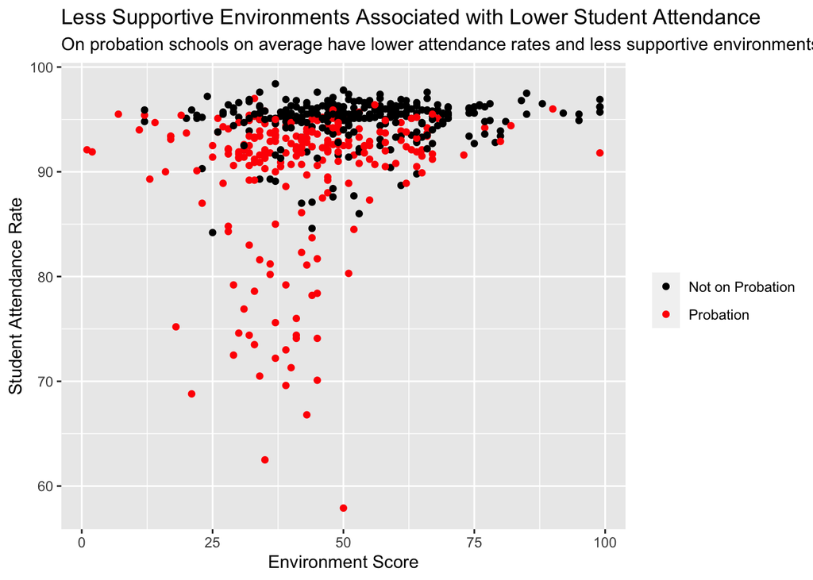

```r
d2 %>% filter(cps_performance_policy_status != "NDA") %>% filter(cps_performance_policy_status != "Not Applicable") %>% ggplot(aes(x = environment_score, y = average_student_attendance,
       color = cps_performance_policy_status)) +
   geom_point() + scale_color_manual(values=c('black','red')) + theme(legend.title=element_blank()) +
  labs(title = "Less Supportive Environments Associated with Lower Student Attendance",
  subtitle = "On probation schools on average have lower attendance rates and less supportive environments",
  x = "Environment Score",
  y = "Student Attendance Rate")
```